# Assignment-6 Indian Statistical Inst-Hyderabad

Certification program on Business Analytics

Mallesham Yamulla

# *Statistical Inferences on Titanic, Mobile Service Provider, Energy drink, and Lung Cancer*

*The below given necessary R packages have been made use of to carry out the statistical test and bring up inferences*

```r
library(tidyverse)
library(readxl)
library(broom)
library(car)
library(infer)
```

*Here first let’s take a look at datasets*

```r
# Glance at titatic dataset

head(titanic_isi)
```

```
## # A tibble: 6 x 14
##   pclass survived                                            name    sex
##    <dbl>    <dbl>                                           <chr>  <chr>
## 1      1        1                   Allen, Miss. Elisabeth Walton female
## 2      1        1                  Allison, Master. Hudson Trevor   male
## 3      1        0                    Allison, Miss. Helen Loraine female
## 4      1        0            Allison, Mr. Hudson Joshua Creighton   male
## 5      1        0 Allison, Mrs. Hudson J C (Bessie Waldo Daniels) female
## 6      1        1                             Anderson, Mr. Harry   male
## # ... with 10 more variables: age <dbl>, `No of Siblings/Spouce` <dbl>,
## #   `No of Parents/children aboard` <dbl>, ticket <chr>, fare <dbl>,
## #   cabin <chr>, embarked <chr>, boat <chr>, `body Bag No` <dbl>,
## #   home.dest <chr>
```

```r
# Glance at mobile service provider

head(movil_claro_isi)
```

```
## # A tibble: 6 x 13
##     Region `Days as Customer` `Age of Customer` `Marital Status`
##      <chr>              <dbl>             <dbl>            <chr>
## 1 Region 3                780                54          Married
## 2 Region 3               1560                64        Unmarried
## 3 Region 3                180                30        Unmarried
## 4 Region 1                810                67        Unmarried
## 5 Region 2               1860                76        Unmarried
## 6 Region 2                660                39        Unmarried
## # ... with 9 more variables: `Income Group` <chr>, Education <chr>,
## #   Gender <chr>, `Land line` <chr>, `Type of Connection` <chr>,
## #   `Discontinued (Churn)` <chr>, `Duration of Call` <dbl>, `Associate
## #   Performance Scores` <dbl>, `Customer Rating` <dbl>
```

```r
# Glance at energy drink

head(energia_cola)
```

```
## # A tibble: 6 x 3
##   Respondent Gender `Brand Preference`
##        <int>  <chr>              <chr>
## 1          1   Male            Brand 3
## 2          2 Female            Brand 3
## 3          3   Male            Brand 3
## 4          4   Male            Brand 1
## 5          5   Male            Brand 1
## 6          6 Female            Brand 2
```

```r
# Glance at lung cancer

head(cancer_isi)
```

```
## # A tibble: 6 x 9
##      ID   TRT   AGE WEIGHIN STAGE TOTALCIN TOTALCW2 TOTALCW4 TOTALCW6
##   <int> <int> <int>   <dbl> <int>    <int>    <int>    <int>    <chr>
## 1     1     0    52   124.0     2        6        6        6        7
## 2     5     0    77   160.0     1        9        6       10        9
## 3     6     0    60   136.5     4        7        9       17       19
## 4     9     0    61   179.6     1        6        7        9        3
## 5    11     0    59   175.8     2        6        7       16       13
## 6    15     0    69   167.6     1        6        6        6       11
```

## Statistical infernces on Titanic Dataset

### Observation- 1

###### *Null hypothesis:* The median fare of a passenger is about $14USD

###### *Alternate hypothesis:* The median fare of a passenger is greater than $14USD

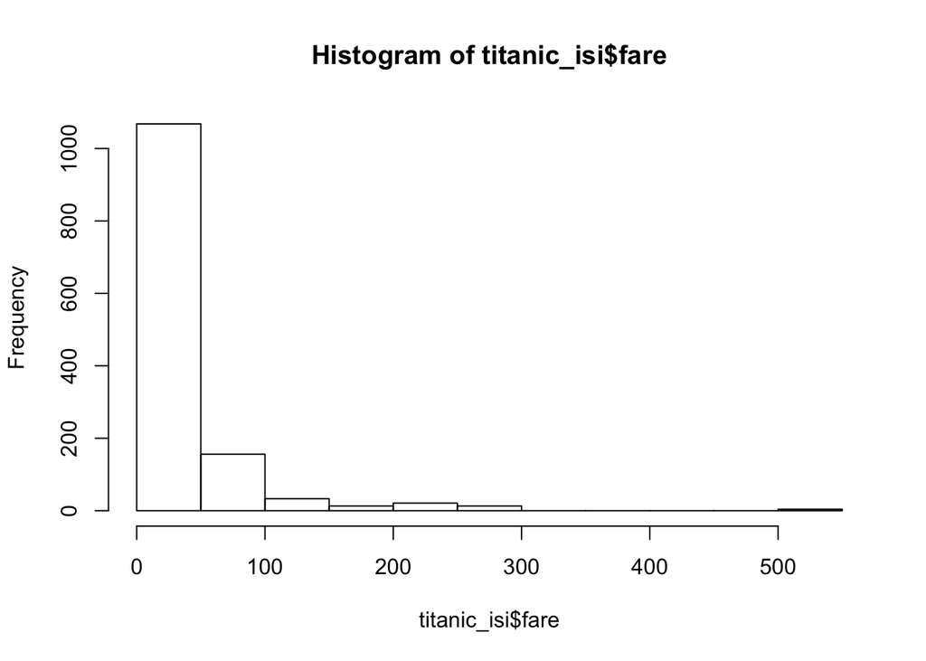

```r
# Visualizing the distribution of data
hist(titanic_isi$fare)
```

```r
# Generate 1000 bootstrap samples centered at null

titanic_hyp_faretest <- titanic_isi %>%
  filter(!is.na(fare)) %>%
  specify(response = fare) %>%
  hypothesize(null = "point",med=14) %>%
  generate(reps = 1000,type = "bootstrap") %>%
  calculate(stat="median")

# Calculate observed mean
fare_med_obs <- titanic_isi%>%
  summarize(median(fare,na.rm = TRUE)) %>%
  # Extract numerical value
  pull()

# # Calculate P-value
titanic_hyp_faretest %>%
  filter(stat > fare_med_obs) %>%
  summarize(n() / 1000)
```

```
## # A tibble: 1 x 1
##   `n()/1000`
##        <dbl>
## 1      0.161
```

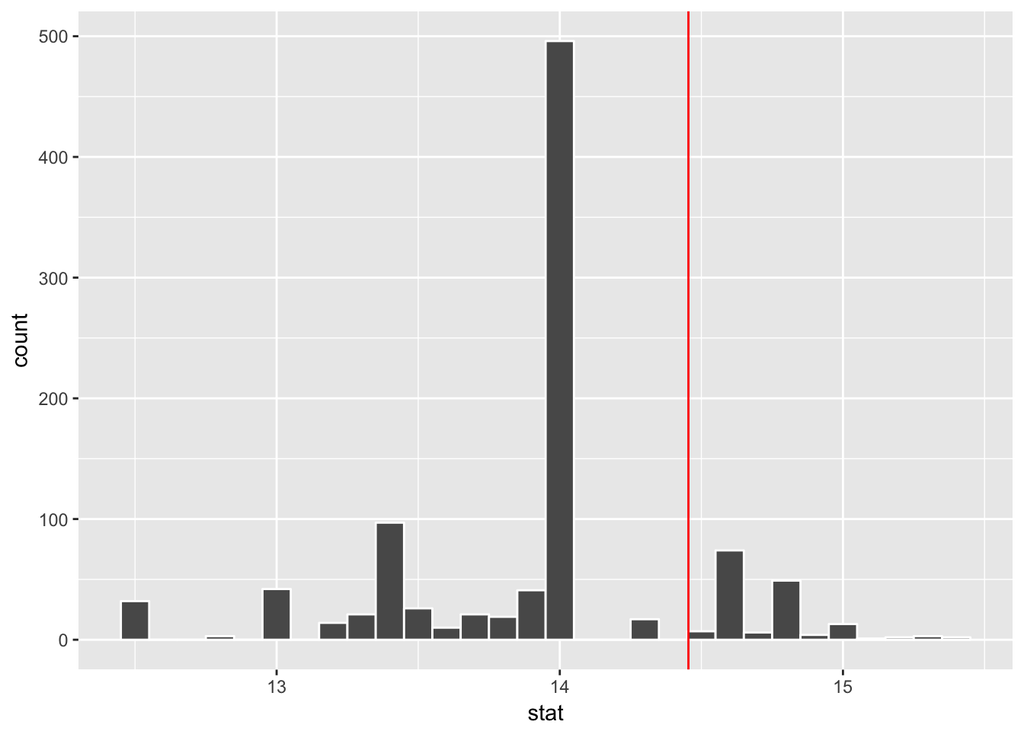

```r
# Visualization

titnanic_vis1 <- titanic_hyp_faretest %>% visualize()

titnanic_vis1 +  geom_vline(color = "red", xintercept = fare_med_obs)
```

> P value caluclated is higher than significance level 0.05, hence we fail reject the null hypothesis.

### Observation- 2

###### *Null hypothesis:* The avg age of a passenger is about 30yrs

###### *Alternate hypothesis:* The avg age of a passenger is more than 30yrs

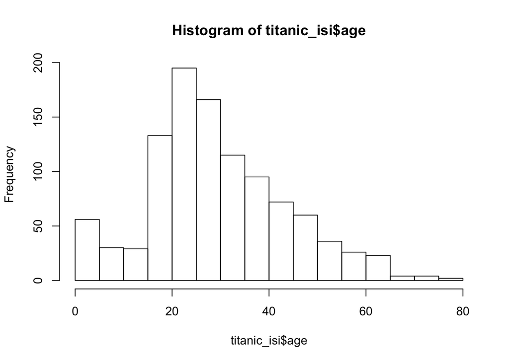

```r
# Visualizing the distribution of data

hist(titanic_isi$age)
```

```r
# Generate 1000 bootstrap samples centered at null

titanic_hyp_agetest <- titanic_isi %>%
  filter(!is.na(age)) %>%
  specify(response = age) %>%
  hypothesize(null = "point",mu=30) %>%
  generate(reps = 1000,type = "bootstrap") %>%
  calculate(stat="mean")

# Calculate observed mean
age_med_obs <- titanic_isi%>%
  summarize(mean(age,na.rm = TRUE)) %>%
  # Extract numerical value
  pull()

# Calculate P-Value
titanic_hyp_agetest %>%
  filter(stat > age_med_obs) %>%
  summarize(n() / 1000)
```

```
## # A tibble: 1 x 1
##   `n()/1000`
##        <dbl>
## 1        0.6
```

```r
# Determine critical value
t_star <- qt(0.975, df = nrow(titanic_isi) - 1)

# Calculate the 95% CI via standard error method

titanic_hyp_agetest %>%
  summarize(boot_se = sd(titanic_hyp_agetest$stat)) %>%
  summarize(l = age_med_obs - t_star * boot_se,
            u = age_med_obs + t_star * boot_se)
```

```
## # A tibble: 1 x 2
##          l        u
##      <dbl>    <dbl>
## 1 29.00243 30.75984
```

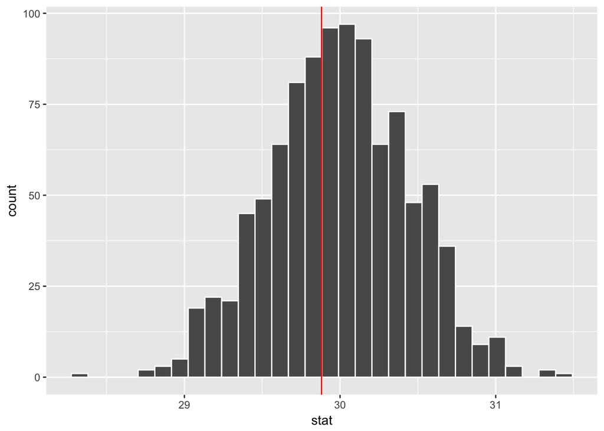

```r
# Visualization

ggplot(titanic_hyp_agetest, aes(x = stat)) +
  geom_histogram(bins = 30, color = "white") +  geom_vline(color = "red", xintercept = age_med_obs)
```

> P value caluclated is higher than significance level 0.05, hence we fail reject the null hypothesis.

> We see that 30 is contained in this confidence interval as a plausible value of μ(the unknown population mean) and .This matches with our hypothesis test results of failing to reject the null hypothesis

### Observation- 3

###### *Null hypothesis:* The avg age of male and female passangers are the same

###### *Alternate hypothesis:* there is a diffence in the avg age of male/female passangers

```r
# Generate 1000 differences in means via randomization
titanic_hyp_group_gen <- titanic_isi %>%
  filter(!is.na(sex),!is.na(age)) %>%
  specify(age ~ sex) %>%
  # Null = no difference between means
  hypothesize(null = "independence") %>%
  # Shuffle labels 1000 times
  generate(reps = 1000, type = "permute") %>%
  # Calculate test statistic
  calculate(stat = "diff in means", order = c("male","female"))

#  Calulcate diff in observed means
titanic_dif_mean <- titanic_isi%>%
  group_by(sex) %>%
  summarize(mean_age = mean(age,na.rm = TRUE)) %>%
  # Extract
  pull() %>%
  # Calculate difference
  diff()

# Calculate p-value
titanic_hyp_group_gen %>%
  # Identify simulated test statistics at least as extreme as observed
  filter(stat < titanic_dif_mean) %>%
  # Calculate p-value
  summarize(p_val = (n() / 1000)) %>%
  pull()
```

```
## [1] 0.98
```

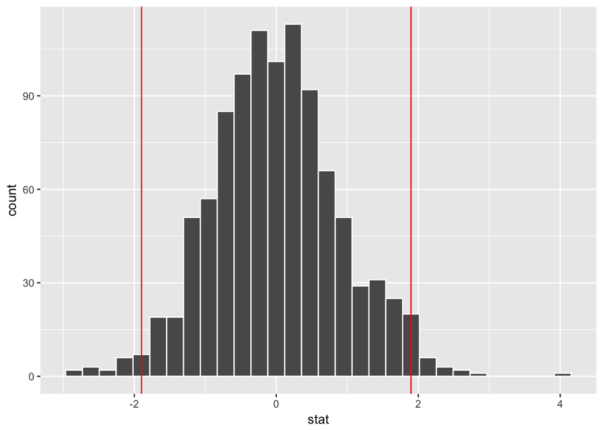

```r
# Visualization

titanic_vis <- titanic_hyp_group_gen %>% visualize()

titanic_vis + geom_vline(aes(xintercept=titanic_dif_mean),col="red") + geom_vline(aes(xintercept=-titanic_dif_mean),col="red")
```

> P value caluclated is higher than significance level 0.05, hence we fail reject the null hypothesis.

### Observation- 4

###### *Null hypothesis:* The avg age of survived and non-survived passengers are the same

###### *Alternate hypothesis:* The avg age of survived and non-survived passengers are not the same

```r
# tranformation of a variable survived
titanic_isi <- titanic_isi %>% as_tibble() %>% mutate(survived = factor(survived))

# Generate 1000 differences in means via randomization
titanic_hyp_group_sur <- titanic_isi %>%
  filter(!is.na(survived),!is.na(age)) %>%
  specify(age ~ survived) %>%
  # Null = no difference between means
  hypothesize(null = "independence") %>%
  # Shuffle labels 1000 times
  generate(reps = 1000, type = "permute") %>%
  # Calculate test statistic
  calculate(stat = "diff in means", order = c("0","1"))

#  Calulcate diff in observed means
titanic_dif_sur_mean <- titanic_isi%>%
  group_by(survived) %>%
  summarize(mean_age = mean(age,na.rm = TRUE)) %>%
  # Extract
  pull() %>%
  # Calculate difference
  diff()

# Calculate p-value
titanic_hyp_group_sur %>%
  # Identify simulated test statistics at least as extreme as observed
  filter(stat < titanic_dif_sur_mean) %>%
  # Calculate p-value
  summarize(p_val = (n() / 1000)) %>%
  pull()
```

```
## [1] 0.035
```

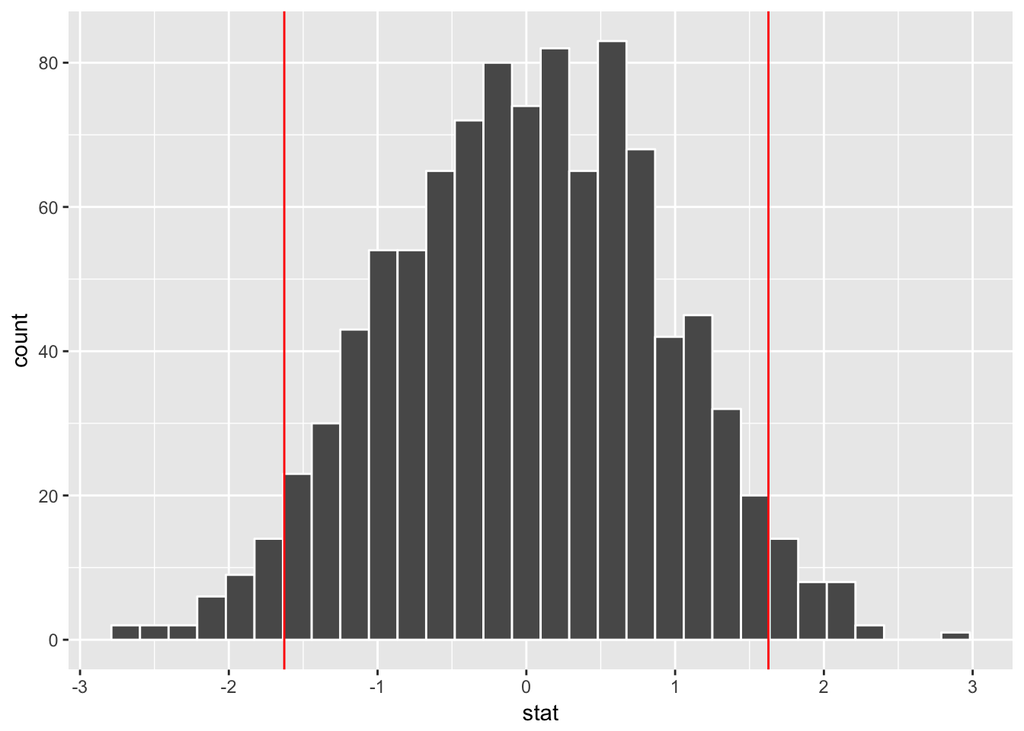

```r
# Visualization -

titanic_vis1 <- titanic_hyp_group_sur %>% visualize()

titanic_vis1 + geom_vline(aes(xintercept=titanic_dif_sur_mean),col="red") + geom_vline(aes(xintercept=-titanic_dif_sur_mean),col="red")
```

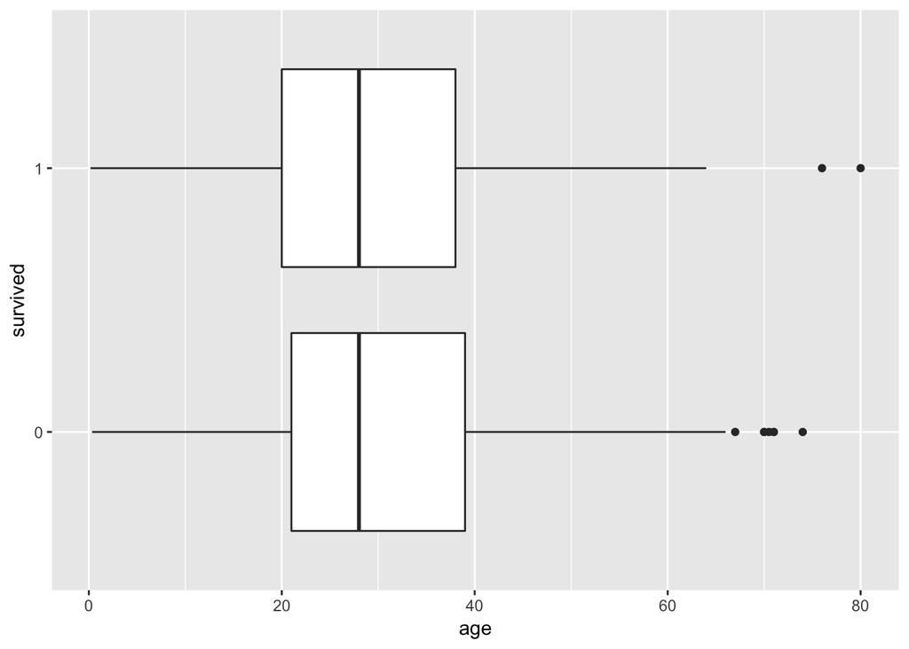

```r
ggplot(titanic_isi,aes(survived,age)) + geom_boxplot() + coord_flip()
```

> P value caluclated is lesser than significance level 0.05, hence we reject the null hypothesis.

### Observation- 5

###### *Null hypothesis:* The avg fare of passengers is the same across all the classes

###### *Alternate hypothesis:* The avg fare of passengers differs between at least one pair of class

```r
titanic_aov_pclass <- aov(fare ~ pclass, data=titanic_isi) %>% tidy()

SST <- titanic_aov_pclass[[1,3]] +titanic_aov_pclass[[2,3]]

titanic_pclass_percentage_of_explained_var <- titanic_aov_pclass[[1,3]] / SST

print(titanic_aov_pclass)
```

```
##        term   df   sumsq      meansq statistic       p.value
## 1    pclass    1 1092668 1092668.222  592.4381 3.266268e-108
## 2 Residuals 1306 2408732    1844.358        NA            NA
```

```r
print(titanic_pclass_percentage_of_explained_var)
```

```
## [1] 0.3120661
```

### Observation- 5

###### *Null hypothesis:* The avg age of passengers is the same across all embarked groups

###### *Alternate hypothesis:* The avg age of passengers differs between at least one pair of embarked groups

```r
titanic_aov_embarked <- aov(age ~ embarked, data=titanic_isi) %>% tidy()

SST <- titanic_aov_embarked[[1,3]] +titanic_aov_embarked[[2,3]]

titanic_emb_percentage_of_explained_var <- titanic_aov_embarked[[1,3]] / SST


print(titanic_aov_embarked)
```

```
##        term   df      sumsq   meansq statistic    p.value
## 1  embarked    2   1666.552 833.2759  4.047179 0.01774723
## 2 Residuals 1041 214332.037 205.8905        NA         NA
```

```r
print(titanic_emb_percentage_of_explained_var)
```

```
## [1] 0.007715568
```

> P value caluclated is smaller than significance level 0.05, hence we reject the null hypothesis.

## Statistical infernces on Mobile Service Provider

### Observation- 1

###### *Null hypothesis:* The median of days as customer are about 800days

###### *Alternate hypothesis:* The median of days as customer are more than 800days

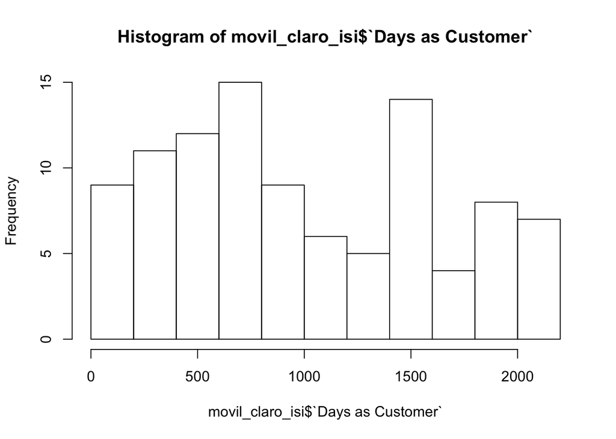

```r
# Visualizing the distribution of data
hist(movil_claro_isi$`Days as Customer`)
```

```r
# Generate 1000 bootstrap samples centered at null
movil_hyp_dac <- movil_claro_isi %>%
  filter(!is.na(`Days as Customer`)) %>%
  specify(response = `Days as Customer`) %>%
  hypothesize(null = "point",med=800) %>%
  generate(reps = 1000,type = "bootstrap") %>%
  calculate(stat="median")

# Caluclate observed median

dac_med_obs <- movil_claro_isi %>%
  summarize(median(`Days as Customer`,na.rm = TRUE)) %>%
  # Extract numerical value
  pull()

# Caluclate P-value

movil_hyp_dac %>%
  filter(stat > dac_med_obs) %>%
  summarize(n() / 1000)
```

```
## # A tibble: 1 x 1
##   `n()/1000`
##        <dbl>
## 1       0.37
```

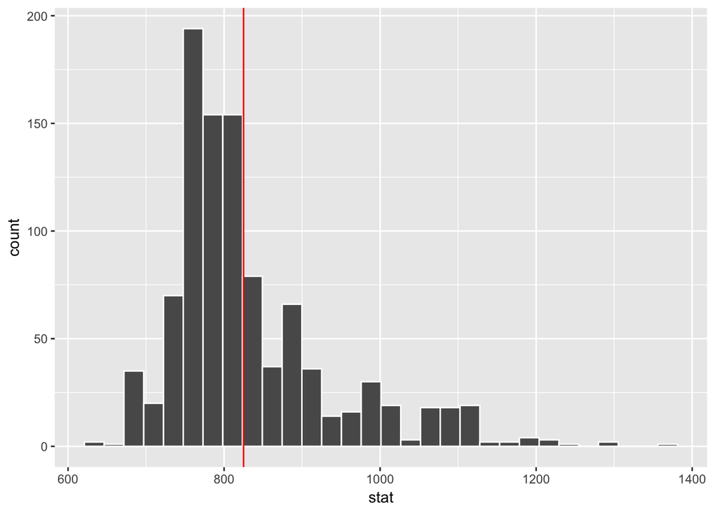

```r
# Visualization

ggplot(movil_hyp_dac, aes(x = stat)) +
  geom_histogram(bins = 30, color = "white") +  geom_vline(color = "red", xintercept = dac_med_obs)
```

> P value caluclated is higher than the significance level 0.05, hence we fail to reject the null hypothesis.

### Observation- 2

###### *Null hypothesis:* The median of days as customer are same in both land line and non-land line connections

###### *Alternate hypothesis:* The median of days as customer are more in non-land connections

```r
# Generate 1000 differences in means via randomization
movil_hyp_group_gen <- movil_claro_isi %>%
  filter(!is.na(`Land line`),!is.na(`Days as Customer`)) %>%
  specify(`Days as Customer` ~ `Land line`) %>%
  # Null = no difference between means
  hypothesize(null = "independence") %>%
  # Shuffle labels 1000 times
  generate(reps = 1000, type = "permute") %>%
  # Calculate test statistic
  calculate(stat = "diff in medians", order = c("Yes","No"))

#  Calulcate diff in observed means
movil_land_dif_mean <- movil_claro_isi%>%
  group_by(`Land line`) %>%
  summarize(median_days = median(`Days as Customer`,na.rm = TRUE)) %>%
  # Extract
  pull() %>%
  # Calculate difference
  diff()

# Calculate p-value
movil_hyp_group_gen %>%
  # Identify simulated test statistics at least as extreme as observed
  filter(stat < movil_land_dif_mean) %>%
  # Calculate p-value
  summarize(p_val = (n() / 1000)) %>%
  pull()
```

```
## [1] 1
```

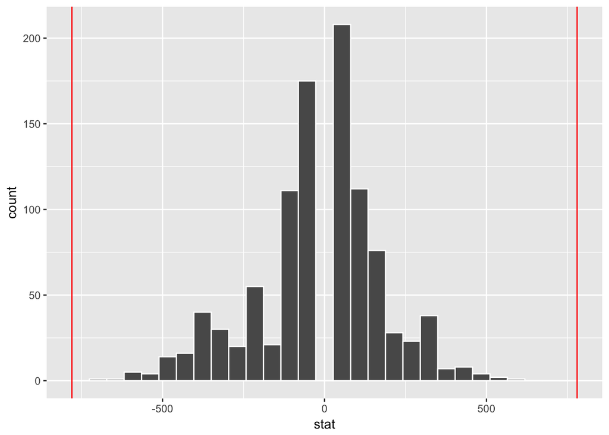

```r
# Visualization

movil_vis <- movil_hyp_group_gen %>% visualize()

movil_vis + geom_vline(aes(xintercept=movil_land_dif_mean),col="red") + geom_vline(aes(xintercept=-movil_land_dif_mean),col="red")
```

### Observation- 3

###### *Null hypothesis:* The median of Days as customers are the same for discontinued and continued customers

###### *Alternate hypothesis:* The median of Days as customers aren’t same for discontinued and continued customers

```r
# Generate 1000 differences in means via randomization
movil_hyp_churn <- movil_claro_isi %>%
  filter(!is.na(`Discontinued (Churn)`),!is.na(`Days as Customer`)) %>%
  specify(`Days as Customer` ~ `Discontinued (Churn)`) %>%
  # Null = no difference between means
  hypothesize(null = "independence") %>%
  # Shuffle labels 1000 times
  generate(reps = 1000, type = "permute") %>%
  # Calculate test statistic
  calculate(stat = "diff in medians", order = c("Yes","No"))

#  Calulcate diff in observed medians
movil_churn_dif_median <- movil_claro_isi%>%
  group_by(`Discontinued (Churn)`) %>%
  summarize(median_days = median(`Days as Customer`,na.rm = TRUE)) %>%
  # Extract
  pull() %>%
  # Calculate difference
  diff()

# Calculate p-value
movil_hyp_churn %>%
  # Identify simulated test statistics at least as extreme as observed
  filter(stat < movil_churn_dif_median) %>%
  # Calculate p-value
  summarize(p_val = (n() / 1000)) %>%
  pull()
```

```
## [1] 0
```

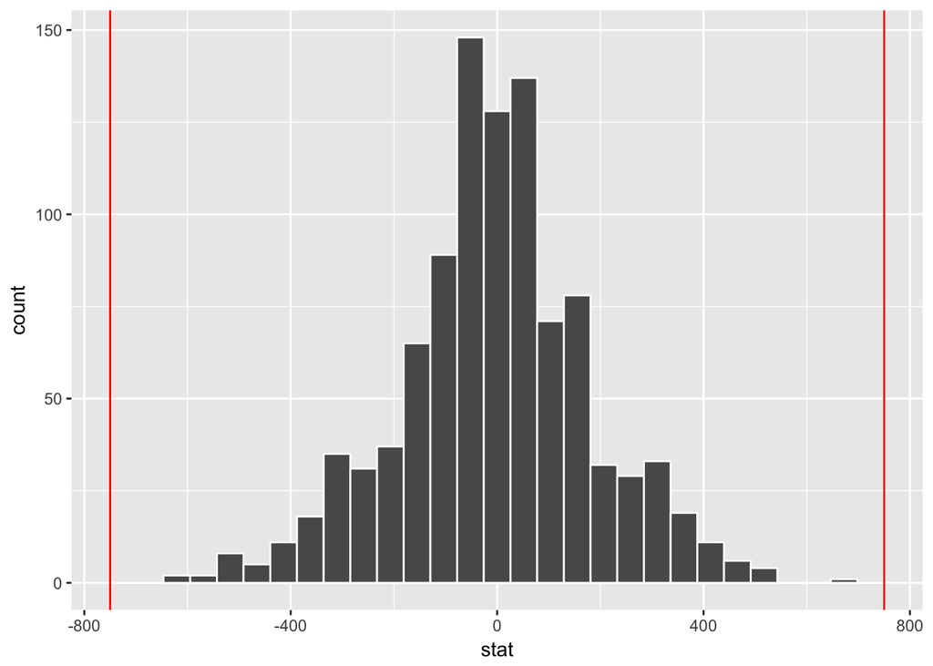

```r
# Visualization

movil_churn_vis <- movil_hyp_churn %>% visualize()

movil_churn_vis + geom_vline(aes(xintercept=movil_churn_dif_median),col="red") + geom_vline(aes(xintercept=-movil_churn_dif_median),col="red")
```

> P value caluclated is lesser than significance level 0.05, hence we reject the null hypothesis.

### Observation- 4

###### *Null hypothesis:* The avg.age of a customer is the same in male and female customers

###### *Alternate hypothesis:* The avg.age of a customer isn’t the same in male and female customers

```r
# Generate 1000 differences in means via randomization
movil_hyp_gender <- movil_claro_isi %>%
  filter(!is.na(Gender),!is.na(`Age of Customer`)) %>%
  specify(`Age of Customer` ~ Gender) %>%
  # Null = no difference between means
  hypothesize(null = "independence") %>%
  # Shuffle labels 1000 times
  generate(reps = 1000, type = "permute") %>%
  # Calculate test statistic
  calculate(stat = "diff in means", order = c("Male","Female"))

#  Calulcate diff in observed means
movil_gender_dif_mean <- movil_claro_isi%>%
  group_by(Gender) %>%
  summarize(mean_days = mean(`Age of Customer`,na.rm = TRUE)) %>%
  # Extract
  pull() %>%
  # Calculate difference
  diff()

# Calculate p-value
movil_hyp_gender %>%
  # Identify simulated test statistics at least as extreme as observed
  filter(stat < movil_gender_dif_mean) %>%
  # Calculate p-value
  summarize(p_val = (n() / 1000)) %>%
  pull()
```

```
## [1] 0.939
```

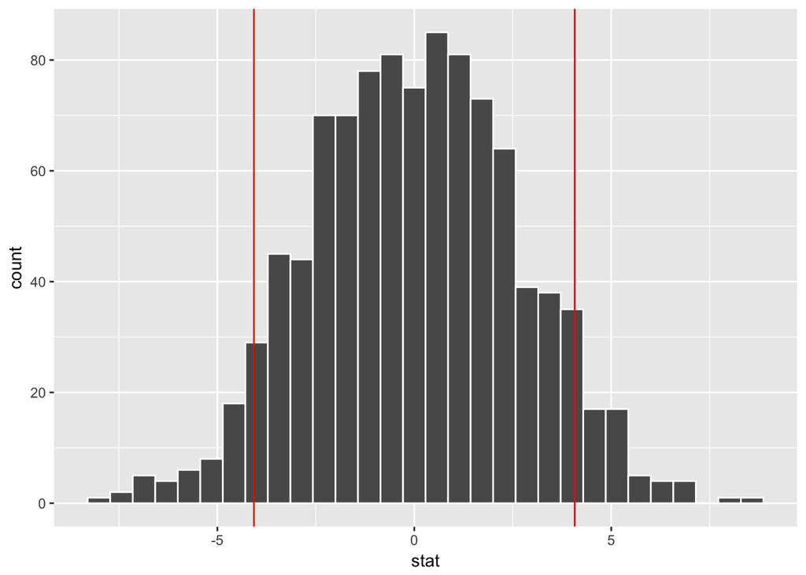

```r
# Visualization -

movil_gender_vis <-movil_hyp_gender %>% visualize()

movil_gender_vis + geom_vline(aes(xintercept=movil_gender_dif_mean),col="red") + geom_vline(aes(xintercept=-movil_gender_dif_mean),col="red")
```

> P value caluclated higher than significance level 0.05, hence we fail to reject the null hypothesis

### Observation- 5

###### *Null hypothesis:* The median of duration of calls the same for married and un-married customers

###### *Alternate hypothesis:* The median of duration of calls in un-married customers are more than married customers

```r
# Generate 1000 differences in means via randomization
movil_hyp_mstat <- movil_claro_isi %>%
  filter(!is.na(`Marital Status`),!is.na(`Duration of Call`)) %>%
  specify(`Duration of Call` ~ `Marital Status`) %>%
  # Null = no difference between means
  hypothesize(null = "independence") %>%
  # Shuffle labels 1000 times
  generate(reps = 1000, type = "permute") %>%
  # Calculate test statistic
  calculate(stat = "diff in medians", order = c("Married","Unmarried"))

#  Calulcate diff in observed medians
movil_mstat_dif_median <- movil_claro_isi%>%
  group_by(`Marital Status`) %>%
  summarize(median_days = median(`Duration of Call`,na.rm = TRUE)) %>%
  # Extract
  pull() %>%
  # Calculate difference
  diff()

# Calculate p-value
movil_hyp_churn %>%
  # Identify simulated test statistics at least as extreme as observed
  filter(stat < movil_mstat_dif_median) %>%
  # Calculate p-value
  summarize(p_val = (n() / 1000)) %>%
  pull()
```

```
## [1] 0.418
```

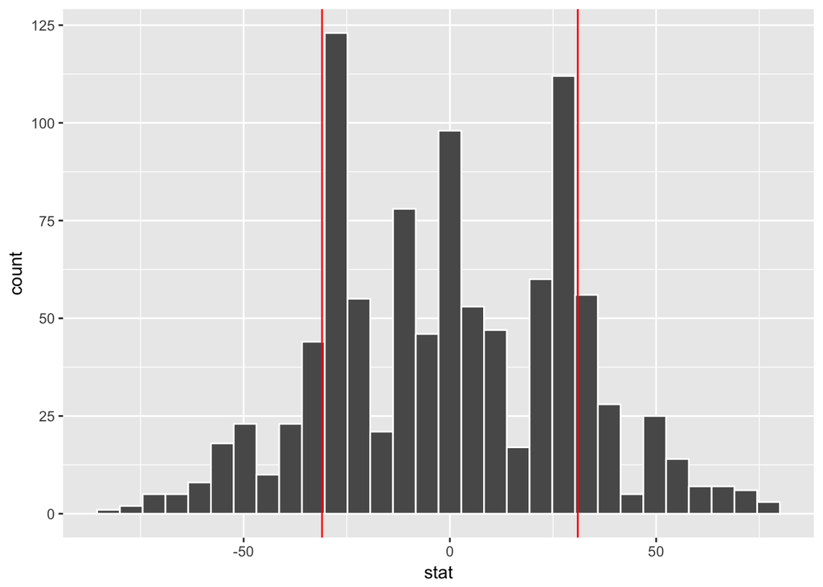

```r
# Visualization -

movil_churn_vis <- movil_hyp_mstat %>% visualize()

movil_churn_vis + geom_vline(aes(xintercept=movil_mstat_dif_median),col="red") + geom_vline(aes(xintercept=-movil_mstat_dif_median),col="red")
```

> P value caluclated higher than significance level 0.05, hence we fail to reject the null hypothesis

### Observation- 6

###### *Null hypothesis:* Does the customer rating differ by male or female

###### *Alternate hypothesis:* Costomet rating isn’t differ by male or female

```r
wilcox.test(movil_claro_isi$`Customer Rating` ~ movil_claro_isi$Gender) %>% tidy()
```

```
##   statistic   p.value                                            method
## 1    1287.5 0.7530883 Wilcoxon rank sum test with continuity correction
##   alternative
## 1   two.sided
```

> P value caluclated higher than significance level 0.05, hence we fail to reject the null hypothesis

### Observation- 7

###### *Null hypothesis:* Does the customer rating differ by continued/discontinued customers ?

###### *Alternate hypothesis:* There is no difference in customer ratings given by continued/discontinued customers

```r
wilcox.test(movil_claro_isi$`Customer Rating` ~ movil_claro_isi$`Discontinued (Churn)`) %>% tidy()
```

```
##   statistic     p.value                                            method
## 1    2069.5 1.15106e-08 Wilcoxon rank sum test with continuity correction
##   alternative
## 1   two.sided
```

### Observation- 8

###### *Null hypothesis:* Does the customer rating differ by region ?

###### *Alternate hypothesis:* There is no difference in customer ratings across regions

```r
kruskal.test(movil_claro_isi$`Customer Rating`, as.factor(movil_claro_isi$Region)) %>% tidy()
```

```
##   statistic   p.value parameter                       method
## 1 0.5687641 0.7524791         2 Kruskal-Wallis rank sum test
```

> P value caluclated higher than significance level 0.05, hence we fail to reject the null hypothesis

### Observation- 9

###### *Null hypothesis:* Does the customer rating differ in type of connection ?

###### *Alternate hypothesis:* There is no difference in customer ratings related to type of connections

```r
kruskal.test(movil_claro_isi$`Customer Rating`, as.factor(movil_claro_isi$`Type of Connection`)) %>% tidy()
```

```
##   statistic  p.value parameter                       method
## 1  2.118314 0.346748         2 Kruskal-Wallis rank sum test
```

> P value caluclated higher than significance level 0.05, hence we fail to reject the null hypothesis

### Observation- 10

###### *Null hypothesis:* The avg no.of days as customers is the same across all type of connections

###### *Alternate hypothesis:* The avg no.of days as customers differs between at least one type of connection

```r
movil_ano_con <- aov(`Days as Customer` ~ `Type of Connection` , movil_claro_isi) %>%  tidy()

SST <- movil_ano_con[[1,3]] + movil_ano_con[[2,3]]

Percentage_of_explained_var_con <- movil_ano_con[[1,3]] / SST

print(movil_ano_con)
```

```
##                   term df    sumsq   meansq statistic   p.value
## 1 `Type of Connection`  2  1211110 605554.8  1.663658 0.1948042
## 2            Residuals 97 35307029 363990.0        NA        NA
```

```r
print(Percentage_of_explained_var_con)
```

```
## [1] 0.0331646
```

> P value caluclated higher than significance level 0.05, hence we failt to reject the null hypothesis

### Observation- 11

###### *Null hypothesis:* The avg of duaration of call is the same across all regions

###### *Alternate hypothesis:* The avg of duaration of call differs between at least in one region

```r
movil_ano_region <- aov(`Duration of Call` ~ Region , movil_claro_isi) %>%  tidy()

SST <- movil_ano_region[[1,3]] + movil_ano_region[[2,3]]

Percentage_of_explained_var_reg <- movil_ano_region[[1,3]] / SST

print(movil_ano_region)
```

```
##        term df      sumsq    meansq statistic   p.value
## 1    Region  2   15086.02  7543.008 0.2166448 0.8056044
## 2 Residuals 97 3377286.73 34817.389        NA        NA
```

```r
print(Percentage_of_explained_var_reg)
```

```
## [1] 0.00444704
```

> P value caluclated higher than significance level 0.05, hence we failt to reject the null hypothesis

### Statistical infernces on Energy drinks

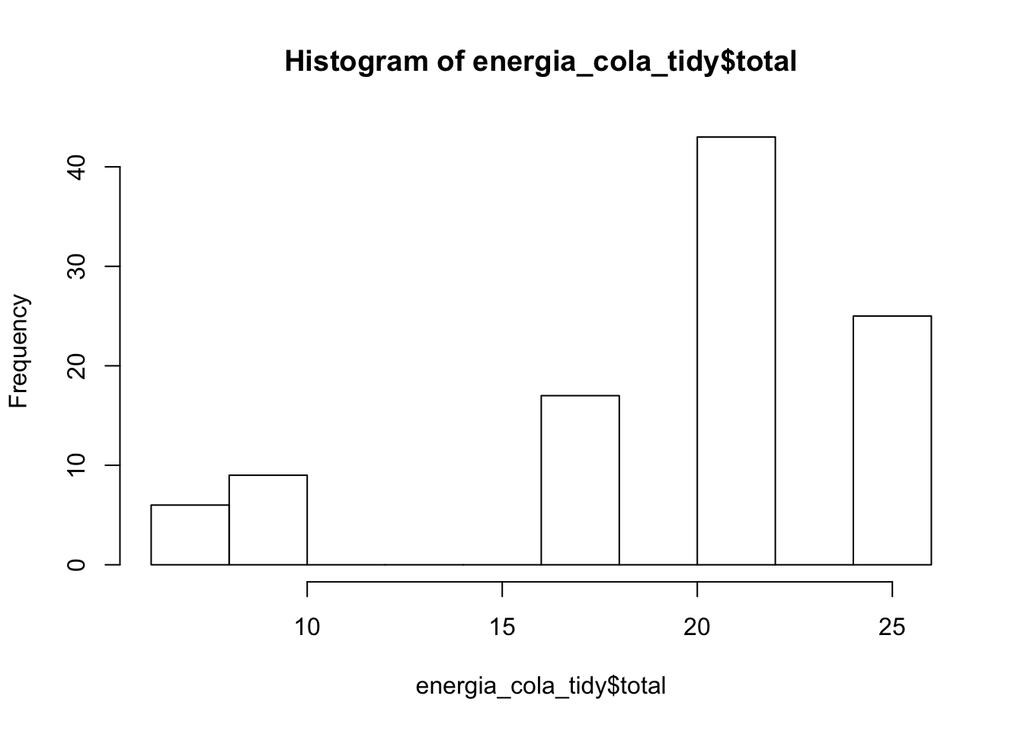

```r
# Data transformations

energia_cola_tidy <- energia_cola %>%
   select(`Brand Preference`,Gender) %>%
  group_by(Gender,`Brand Preference`) %>%
  mutate(total=n())


# Visualizing the distribution of data

hist(energia_cola_tidy$total)
```

### Observation- 1

###### *Null hypothesis:* The energy drinks are eqaully preffered in male and female groups.

###### *Alternate hypothesis:* The energy drinks aren’t eqaully preffered in male and female groups

```r
leveneTest(total ~ Gender,data=energia_cola_tidy) %>% tidy()
```

```
##    term df statistic     p.value
## 1 group  1  10.61546 0.001541713
## 2       98        NA          NA
```

> P value caluclated is lesser than significance level 0.05, hence we reject the null hypothesis.

### Observation- 2

###### *Null hypothesis:* Brand preferences are equall in the customers

###### *Alternate hypothesis:* Brand preferences aren’t equall in the customers

```r
aov(total ~ `Brand Preference`,data=energia_cola_tidy) %>% tidy()
```

```
##                 term df     sumsq    meansq statistic      p.value
## 1 `Brand Preference`  2  891.1695 445.58474  19.28275 8.895972e-08
## 2          Residuals 97 2241.4705  23.10794        NA           NA
```

### Statistical infernces on Lung Cancer

### Observation- 1

###### *Null hypothesis:* The avg age of a cancer patient is about 60years

###### *Alternate hypothesis:* The avg age of a cancer patient is more than 60years

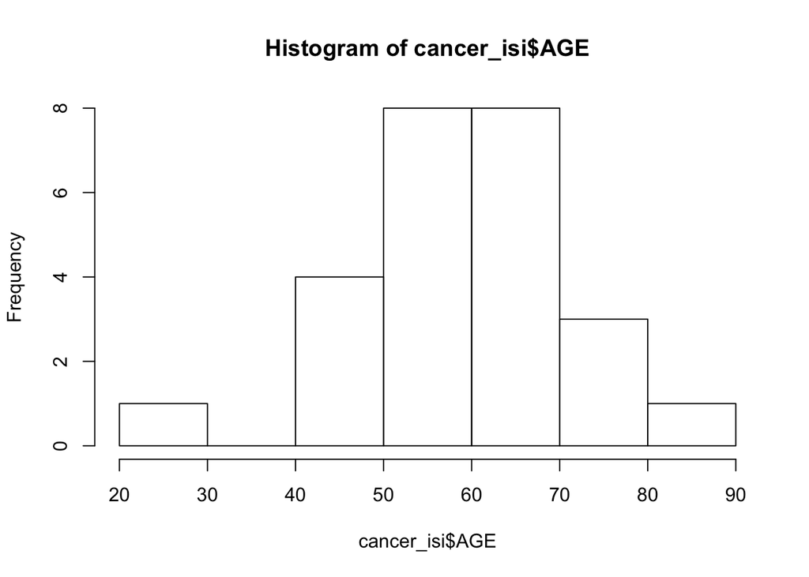

```r
# Visualizing the distribution of data

hist(cancer_isi$AGE)
```

```r
# Generate 1000 bootstrap samples centered at null
cancer_hyp_age <- cancer_isi %>%
  filter(!is.na(AGE)) %>%
  specify(response = AGE) %>%
  hypothesize(null = "point",mu=60) %>%
  generate(reps = 1000,type = "bootstrap") %>%
  calculate(stat="mean")

#Observed mean
age_me_obs_can <- cancer_isi%>%
    summarize(mean(AGE,na.rm = TRUE)) %>%
  # Extract numerical value
  pull()

#P-value
cancer_hyp_age %>%
  filter(stat > age_me_obs_can) %>%
  summarize(n() / 1000)
```

```
## # A tibble: 1 x 1
##   `n()/1000`
##        <dbl>
## 1      0.567
```

```r
# Determine critical value
t_star <- qt(0.975, df = nrow(cancer_isi) - 1)

# Calculate the 95% CI via standard error method

cancer_hyp_age %>%
  summarize(boot_se = sd(cancer_hyp_age$stat)) %>%
  summarize(l = age_me_obs_can - t_star * boot_se,
            u = age_me_obs_can + t_star * boot_se)
```

```
## # A tibble: 1 x 2
##          l        u
##      <dbl>    <dbl>
## 1 54.44233 64.83767
```

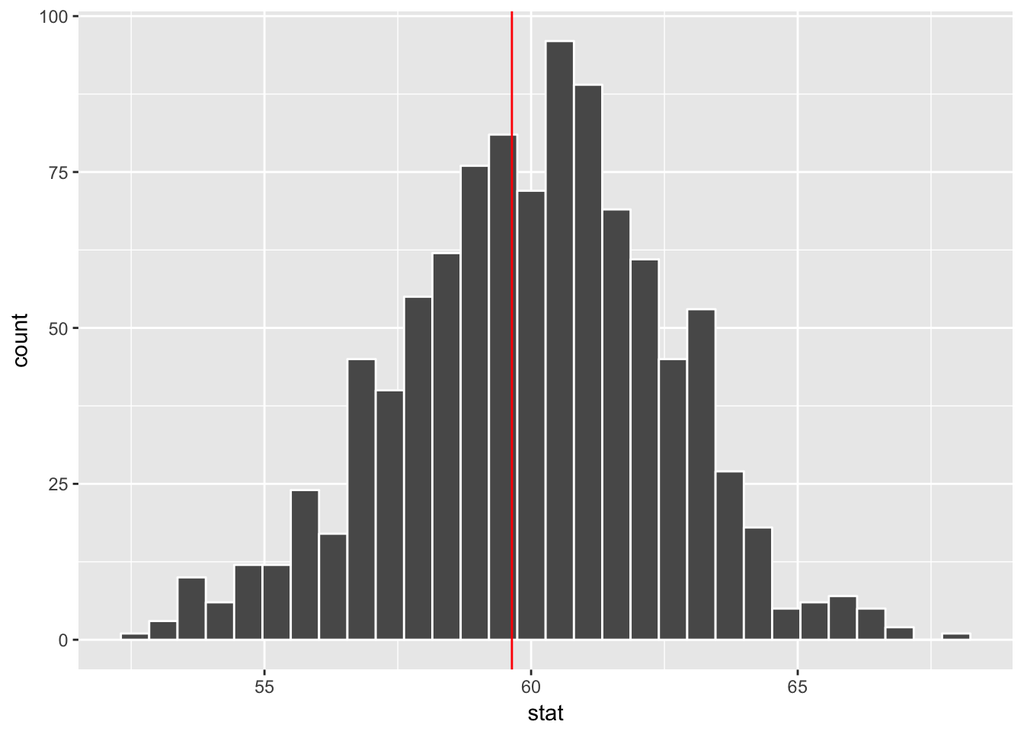

```r
cancer_vis <- cancer_hyp_age %>% visualize()

cancer_vis +  geom_vline(color = "red", xintercept = age_me_obs_can)
```

> P value caluclated higher than significance level 0.05, hence we fail to reject the null hypothesis

### Observation- 2

###### *Null hypothesis:* The avg ages are the same for treatement and non-treatment patients

###### *Alternate hypothesis:* The avg ages aren’t the same for treatement and non-treatment patients

```r
cancer_isi <- cancer_isi %>% as_tibble() %>% mutate(TRT = factor(TRT))

# Generate 1000 differences in means via randomization
cancer_hyp_trt<- cancer_isi %>%
  filter(!is.na(TRT),!is.na(AGE)) %>%
  specify(AGE ~ TRT) %>%
  # Null = no difference between means
  hypothesize(null = "independence") %>%
  # Shuffle labels 1000 times
  generate(reps = 1000, type = "permute") %>%
  # Calculate test statistic
  calculate(stat = "diff in means", order = c("0","1"))

#  Calulcate diff in observed means
cancer_dif_mean <- cancer_isi%>%
  group_by(TRT) %>%
  summarize(mean_age = mean(AGE,na.rm = TRUE)) %>%
  # Extract
  pull() %>%
  # Calculate difference
  diff()

# Calculate p-value
cancer_hyp_trt %>%
  # Identify simulated test statistics at least as extreme as observed
  filter(stat < cancer_dif_mean) %>%
  # Calculate p-value
  summarize(p_val = (n() / 1000)) %>%
  pull()
```

```
## [1] 0.495
```

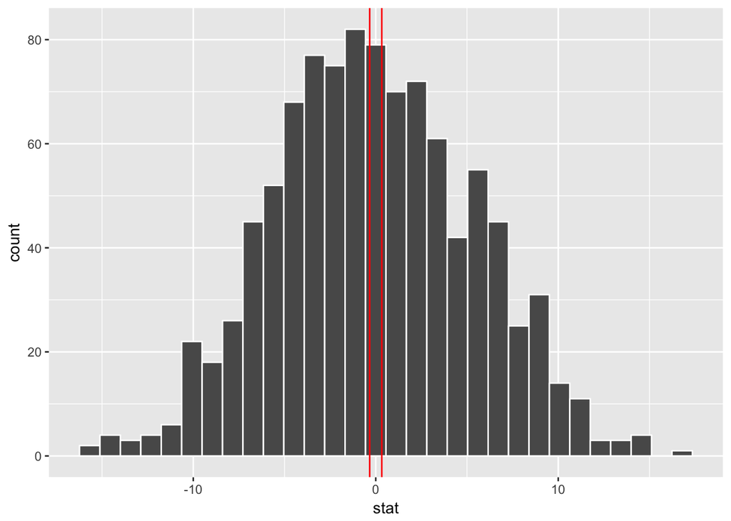

```r
# Visualization -

cancer_trt_vis <- cancer_hyp_trt %>% visualize()

cancer_trt_vis + geom_vline(aes(xintercept=cancer_dif_mean),col="red") + geom_vline(aes(xintercept=-cancer_dif_mean),col="red")
```

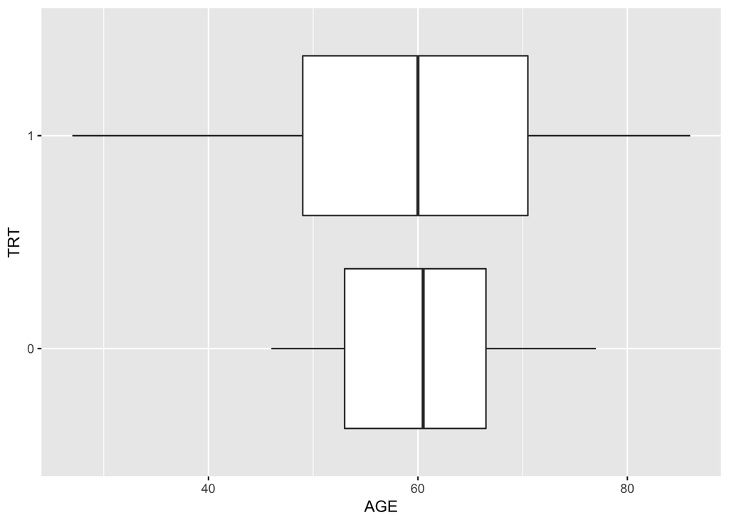

```r
ggplot(cancer_isi,aes(TRT,AGE)) + geom_boxplot() + coord_flip()
```

> P value caluclated higher than significance level 0.05, hence we fail to reject the null hypothesis

### Observation- 3

###### *Null hypothesis:* The avg weights are the same for treatement and non-treatment patients

###### *Alternate hypothesis:* The avg weights aren’t the same for treatement and non-treatment patients

```r
# Generate 1000 differences in means via randomization
cancer_hyp_trt_weight<- cancer_isi %>%
  filter(!is.na(TRT),!is.na(WEIGHIN)) %>%
  specify(WEIGHIN ~ TRT) %>%
  # Null = no difference between means
  hypothesize(null = "independence") %>%
  # Shuffle labels 1000 times
  generate(reps = 1000, type = "permute") %>%
  # Calculate test statistic
  calculate(stat = "diff in means", order = c("0","1"))

#  Calulcate diff in observed means
cancer_dif_mean_we <- cancer_isi%>%
  group_by(TRT) %>%
  summarize(mean_wei= mean(WEIGHIN,na.rm = TRUE)) %>%
  # Extract
  pull() %>%
  # Calculate difference
  diff()

# Calculate p-value
cancer_hyp_trt_weight %>%
  # Identify simulated test statistics at least as extreme as observed
  filter(stat < cancer_dif_mean_we) %>%
  # Calculate p-value
  summarize(p_val = (n() / 1000)) %>%
  pull()
```

```
## [1] 0.981
```

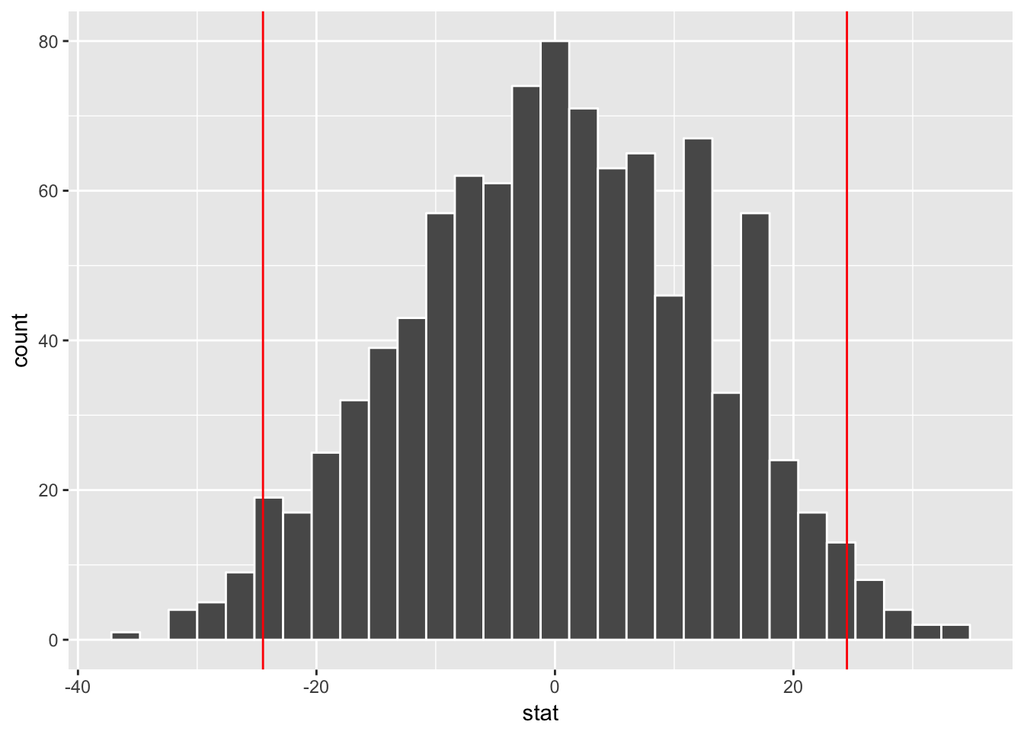

```r
# Visualization -

cancer_trt_weight_vis <- cancer_hyp_trt_weight %>% visualize()

cancer_trt_weight_vis + geom_vline(aes(xintercept=cancer_dif_mean_we),col="red") + geom_vline(aes(xintercept=-cancer_dif_mean_we),col="red")
```

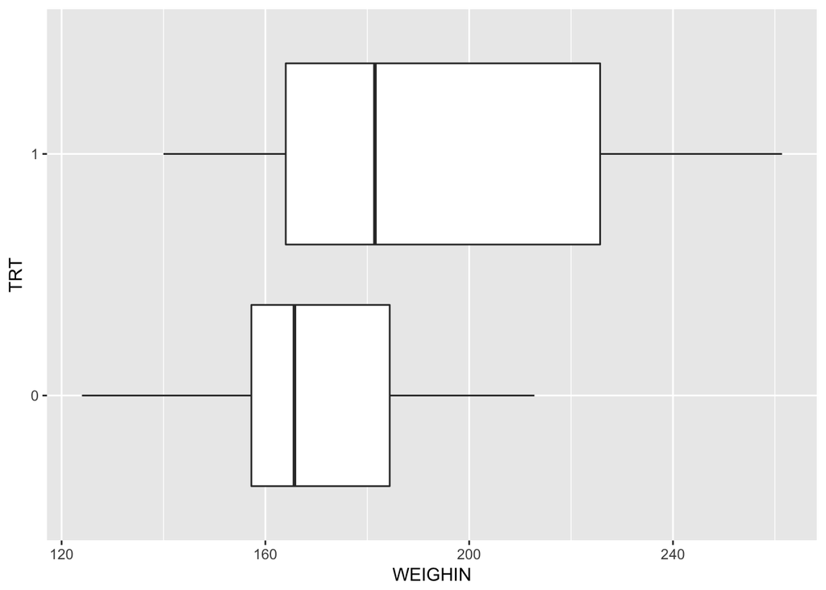

```r
ggplot(cancer_isi,aes(TRT, WEIGHIN)) + geom_boxplot() + coord_flip()
```

> P value caluclated higher than significance level 0.05, hence we fail to reject the null hypothesis

### Observation- 4

###### *Null hypothesis:* The avg weights of patients are the same across all stages of cancer

###### *Alternate hypothesis:* The avg weights of patients days differe between at least one stage of cancer

```r
cancer_ano_stage  <- aov(WEIGHIN ~ STAGE, data=cancer_isi) %>% tidy()


SST <- cancer_ano_stage[[1,3]] + cancer_ano_stage[[2,3]]

Percentage_of_explained_var_statge <- cancer_ano_stage[[1,3]] / SST

print(cancer_ano_stage)
```

```
##        term df        sumsq       meansq    statistic   p.value
## 1     STAGE  1 6.986900e-04 6.986900e-04 6.548455e-07 0.9993613
## 2 Residuals 23 2.453994e+04 1.066954e+03           NA        NA
```

```r
print(Percentage_of_explained_var_statge)
```

```
## [1] 2.847154e-08
```

> P value caluclated higher than significance level 0.05, hence we fail to reject the null hypothesis

## *Introduction to statistical learning*

Statistical learning refers to a vast set of tools for understanding data. these tools can be classified as below

- Supervised
- Unsupervised

###### **Supervised Learning**

The majority of practical machine learning uses supervised learning.

Supervised learning is where you have input variables (x) and an output variable (Y) and you use an algorithm to learn the mapping function from the input to the output.

Y = f(X)

The goal is to approximate the mapping function so well that when you have new input data (x) that you can predict the output variables (Y) for that data.

It is called supervised learning because the process of an algorithm learning from the training dataset can be thought of as a teacher supervising the learning process. We know the correct answers, the algorithm iteratively makes predictions on the training data and is corrected by the teacher. Learning stops when the algorithm achieves an acceptable level of performance.

Supervised learning problems can be further grouped into regression and classification problems.

**Classification**: A classification problem is when the output variable is a category, such as “red” or “blue” or “disease” and “no disease”.

**Regression**: A regression problem is when the output variable is a real value, such as “dollars” or “weight”.

Some common types of problems built on top of classification and regression include recommendation and time series prediction respectively.

Some popular examples of supervised machine learning algorithms are:

1. Linear regression for regression problems.
2. Random forest for classification and regression problems.
3. Support vector machines for classification problems.

###### **Unsupervised Learning**

Unsupervised learning is where you only have input data (X) and no corresponding output variables.

The goal for unsupervised learning is to model the underlying structure or distribution in the data in order to learn more about the data.

These are called unsupervised learning because unlike supervised learning above there is no correct answers and there is no teacher. Algorithms are left to their own devises to discover and present the interesting structure in the data.

Unsupervised learning problems can be further grouped into clustering and association problems.

**Clustering**: A clustering problem is where you want to discover the inherent groupings in the data, such as grouping customers by purchasing behavior.

**Association**: An association rule learning problem is where you want to discover rules that describe large portions of your data, such as people that buy X also tend to buy Y.

Some popular examples of unsupervised learning algorithms are:

1. k-means for clustering problems.
2. Apriori algorithm for association rule learning problems.

### THE END - THANKS - MALLESHAM YAMULLA - SENIOR SECURITY ANALYST